# Bellabeat Case Study

Ekta Jain

3/29/2022

# Bellabeat Case Study

## About a company

A high-tech manufacturer of health-focused, designed technology that informs and inspires women around the world. Collecting data on activity, sleep, stress, and reproductive health has allowed Bellabeat to empower women with knowledge about their health and habits. Since it was founded in 2013, Bellabeat has grown rapidly and quickly positioned itself as a tech-driven wellness company for women.

## Question for the analysis

- 1. What are some trends in smart device usage?
- 2. How could these trends apply to Bellabeat customers?
- 3. How could these trends help influence Bellabeat marketing strategy?

## PHASE 1: ASK

### Key objectives

- Identify the business task:

The company better target their marketing efforts to their customer’s needs based on their usage of their fitness smart devices. With this info then make high-level recommendations for how these trends can inform Bellabeat marketing strategy.

- Consider key stakeholders:

The main stakeholders here are Urška Sršen, Bellabeat’s co-founder and Chief Creative Officer; Sando Mur, Mathematician, and Bellabeat’s cofounder; And the rest of the Bellabeat marketing analytics team.

- The business task:

Identify potential opportunities for growth and recommendations for the Bellabeat marketing strategy improvement based on trends in smart device usage.

## PHASE 2: Prepare

### Key objectives

- Setting up my R environment by loading the packages and data from Fitbit Fitness Tracker
- Determine the credibility of the data:
- Sort and filter the data:

### Setting up my R enviroment

```r
library(tidyverse)
library(lubridate)
```

```r
library(ggplot2)
library(tidyr)
library(readr)
library(dplyr)
library(here)
library(skimr)
library(janitor)
```

### Import data

- The data is public data from FitBit Fitness Tracker Data. It’s a dataset from thirty fitbit users that includes minute-level output for physical activity, heart rate, and sleep monitoring.

```r
activity <- read_csv("dailyActivity_merged.csv")
calories <- read_csv("dailyCalories_merged.csv")
intensities <- read_csv("dailyIntensities_merged.csv")
steps <- read_csv("dailySteps_merged.csv")
sleep <- read_csv("sleepDay_merged.csv")
weight <- read_csv("weightLogInfo_merged.csv")
```

### Determine the credibility of the data

#### Data Source

- Fitbit Fitness Tracker Data (CC0: Public Domain, dataset made available through Möbius)
- 18 datasets were generated by respondents to a distributed survey via Amazon Mechanical Turk between 03.12.2016-05.12.2016.
- 30 eligible Fitbit users consented to the submission of personal tracker data, including minute-level output for physical activity, heart rate, and sleep monitoring.

## PHASE 3: Process

### Key tasks

- Check the data for errors.
- Choose my tools.
- Transform the data so I can work with it effectively.
- Document the cleaning process.

### Separate date and time column and View data frame

```r
sleep1 <- separate(sleep, SleepDay, into = c("Date", "Time"), sep= " ")
head(sleep1)
```

```
## # A tibble: 6 x 6
##           Id Date      Time     TotalSleepRecor~ TotalMinutesAsl~ TotalTimeInBed
##        <dbl> <chr>     <chr>               <dbl>            <dbl>          <dbl>
## 1 1503960366 4/12/2016 12:00:00                1              327            346
## 2 1503960366 4/13/2016 12:00:00                2              384            407
## 3 1503960366 4/15/2016 12:00:00                1              412            442
## 4 1503960366 4/16/2016 12:00:00                2              340            367
## 5 1503960366 4/17/2016 12:00:00                1              700            712
## 6 1503960366 4/19/2016 12:00:00                1              304            320
```

```r
weight1 <- separate(weight, Date, into = c("Date", "Time"), sep = " ")
head(weight1)
```

```
## # A tibble: 6 x 9
##          Id Date  Time  WeightKg WeightPounds   Fat   BMI IsManualReport   LogId
##       <dbl> <chr> <chr>    <dbl>        <dbl> <dbl> <dbl> <lgl>            <dbl>
## 1    1.50e9 5/2/~ 11:5~     52.6         116.    22  22.6 TRUE           1.46e12
## 2    1.50e9 5/3/~ 11:5~     52.6         116.    NA  22.6 TRUE           1.46e12
## 3    1.93e9 4/13~ 1:08~    134.          294.    NA  47.5 FALSE          1.46e12
## 4    2.87e9 4/21~ 11:5~     56.7         125.    NA  21.5 TRUE           1.46e12
## 5    2.87e9 5/12~ 11:5~     57.3         126.    NA  21.7 TRUE           1.46e12
## 6    4.32e9 4/17~ 11:5~     72.4         160.    25  27.5 TRUE           1.46e12
```

### Rename columns

```r
steps1 <- rename (steps, "Date" = ActivityDay)
steps1 <- rename (steps1, "TotalSteps" = StepTotal)
head(steps1)
```

```
## # A tibble: 6 x 3
##           Id Date      TotalSteps
##        <dbl> <chr>          <dbl>
## 1 1503960366 4/12/2016      13162
## 2 1503960366 4/13/2016      10735
## 3 1503960366 4/14/2016      10460
## 4 1503960366 4/15/2016       9762
## 5 1503960366 4/16/2016      12669
## 6 1503960366 4/17/2016       9705
```

```r
activity1 <- rename(activity, "Date" = ActivityDate)
head(activity1)
```

```
## # A tibble: 6 x 15
##           Id Date      TotalSteps TotalDistance TrackerDistance LoggedActivitie~
##        <dbl> <chr>          <dbl>         <dbl>           <dbl>            <dbl>
## 1 1503960366 4/12/2016      13162          8.5             8.5                 0
## 2 1503960366 4/13/2016      10735          6.97            6.97                0
## 3 1503960366 4/14/2016      10460          6.74            6.74                0
## 4 1503960366 4/15/2016       9762          6.28            6.28                0
## 5 1503960366 4/16/2016      12669          8.16            8.16                0
## 6 1503960366 4/17/2016       9705          6.48            6.48                0
## # ... with 9 more variables: VeryActiveDistance <dbl>,
## #   ModeratelyActiveDistance <dbl>, LightActiveDistance <dbl>,
## #   SedentaryActiveDistance <dbl>, VeryActiveMinutes <dbl>,
## #   FairlyActiveMinutes <dbl>, LightlyActiveMinutes <dbl>,
## #   SedentaryMinutes <dbl>, Calories <dbl>
```

```r
calories1 <- rename(calories, "Date" = ActivityDay)
head(calories1)
```

```
## # A tibble: 6 x 3
##           Id Date      Calories
##        <dbl> <chr>        <dbl>
## 1 1503960366 4/12/2016     1985
## 2 1503960366 4/13/2016     1797
## 3 1503960366 4/14/2016     1776
## 4 1503960366 4/15/2016     1745
## 5 1503960366 4/16/2016     1863
## 6 1503960366 4/17/2016     1728
```

```r
intensities1 <- rename(intensities, "Date" = ActivityDay)
head(intensities1)
```

```
## # A tibble: 6 x 10
##           Id Date      SedentaryMinutes LightlyActiveMinutes FairlyActiveMinutes
##        <dbl> <chr>                <dbl>                <dbl>               <dbl>
## 1 1503960366 4/12/2016              728                  328                  13
## 2 1503960366 4/13/2016              776                  217                  19
## 3 1503960366 4/14/2016             1218                  181                  11
## 4 1503960366 4/15/2016              726                  209                  34
## 5 1503960366 4/16/2016              773                  221                  10
## 6 1503960366 4/17/2016              539                  164                  20
## # ... with 5 more variables: VeryActiveMinutes <dbl>,
## #   SedentaryActiveDistance <dbl>, LightActiveDistance <dbl>,
## #   ModeratelyActiveDistance <dbl>, VeryActiveDistance <dbl>
```

### join all 6 tables data. They share the columns so it easy to simply merge them and drop time column

```r
activity_calories <- merge(activity1, calories1, by = c( "Id", "Calories", "Date"))
head(activity_calories)
```

```
##           Id Calories      Date TotalSteps TotalDistance TrackerDistance
## 1 1503960366        0 5/12/2016          0          0.00            0.00
## 2 1503960366     1728 4/17/2016       9705          6.48            6.48
## 3 1503960366     1740  5/8/2016      10060          6.58            6.58
## 4 1503960366     1745 4/15/2016       9762          6.28            6.28
## 5 1503960366     1775 4/21/2016       9819          6.34            6.34
## 6 1503960366     1776 4/14/2016      10460          6.74            6.74
##   LoggedActivitiesDistance VeryActiveDistance ModeratelyActiveDistance
## 1                        0               0.00                     0.00
## 2                        0               3.19                     0.78
## 3                        0               3.53                     0.32
## 4                        0               2.14                     1.26
## 5                        0               1.34                     0.35
## 6                        0               2.44                     0.40
##   LightActiveDistance SedentaryActiveDistance VeryActiveMinutes
## 1                0.00                       0                 0
## 2                2.51                       0                38
## 3                2.73                       0                44
## 4                2.83                       0                29
## 5                4.65                       0                19
## 6                3.91                       0                30
##   FairlyActiveMinutes LightlyActiveMinutes SedentaryMinutes
## 1                   0                    0             1440
## 2                  20                  164              539
## 3                   8                  203              574
## 4                  34                  209              726
## 5                   8                  211              838
## 6                  11                  181             1218
```

```r
activity_calories_intensities <- merge(activity_calories, intensities1, by = c(
  "Id", "Date", "SedentaryMinutes", "LightlyActiveMinutes", "FairlyActiveMinutes",
  "VeryActiveMinutes", "SedentaryActiveDistance", "LightActiveDistance",
  "ModeratelyActiveDistance", "VeryActiveDistance" ))
head(activity_calories_intensities)
```

```
##           Id      Date SedentaryMinutes LightlyActiveMinutes
## 1 1503960366 4/12/2016              728                  328
## 2 1503960366 4/13/2016              776                  217
## 3 1503960366 4/14/2016             1218                  181
## 4 1503960366 4/15/2016              726                  209
## 5 1503960366 4/16/2016              773                  221
## 6 1503960366 4/17/2016              539                  164
##   FairlyActiveMinutes VeryActiveMinutes SedentaryActiveDistance
## 1                  13                25                       0
## 2                  19                21                       0
## 3                  11                30                       0
## 4                  34                29                       0
## 5                  10                36                       0
## 6                  20                38                       0
##   LightActiveDistance ModeratelyActiveDistance VeryActiveDistance Calories
## 1                6.06                     0.55               1.88     1985
## 2                4.71                     0.69               1.57     1797
## 3                3.91                     0.40               2.44     1776
## 4                2.83                     1.26               2.14     1745
## 5                5.04                     0.41               2.71     1863
## 6                2.51                     0.78               3.19     1728
##   TotalSteps TotalDistance TrackerDistance LoggedActivitiesDistance
## 1      13162          8.50            8.50                        0
## 2      10735          6.97            6.97                        0
## 3      10460          6.74            6.74                        0
## 4       9762          6.28            6.28                        0
## 5      12669          8.16            8.16                        0
## 6       9705          6.48            6.48                        0
```

```r
activity_calories_intensities_steps <- merge(activity_calories_intensities, steps1,
by = c("Id", "Date", "TotalSteps"))
head(activity_calories_intensities_steps)
```

```
##           Id      Date TotalSteps SedentaryMinutes LightlyActiveMinutes
## 1 1503960366 4/12/2016      13162              728                  328
## 2 1503960366 4/13/2016      10735              776                  217
## 3 1503960366 4/14/2016      10460             1218                  181
## 4 1503960366 4/15/2016       9762              726                  209
## 5 1503960366 4/16/2016      12669              773                  221
## 6 1503960366 4/17/2016       9705              539                  164
##   FairlyActiveMinutes VeryActiveMinutes SedentaryActiveDistance
## 1                  13                25                       0
## 2                  19                21                       0
## 3                  11                30                       0
## 4                  34                29                       0
## 5                  10                36                       0
## 6                  20                38                       0
##   LightActiveDistance ModeratelyActiveDistance VeryActiveDistance Calories
## 1                6.06                     0.55               1.88     1985
## 2                4.71                     0.69               1.57     1797
## 3                3.91                     0.40               2.44     1776
## 4                2.83                     1.26               2.14     1745
## 5                5.04                     0.41               2.71     1863
## 6                2.51                     0.78               3.19     1728
##   TotalDistance TrackerDistance LoggedActivitiesDistance
## 1          8.50            8.50                        0
## 2          6.97            6.97                        0
## 3          6.74            6.74                        0
## 4          6.28            6.28                        0
## 5          8.16            8.16                        0
## 6          6.48            6.48                        0
```

```r
sleep_weight <- full_join(sleep1, weight1)
head(sleep_weight)
```

```
## # A tibble: 6 x 12
##         Id Date  Time  TotalSleepRecor~ TotalMinutesAsl~ TotalTimeInBed WeightKg
##      <dbl> <chr> <chr>            <dbl>            <dbl>          <dbl>    <dbl>
## 1   1.50e9 4/12~ 12:0~                1              327            346       NA
## 2   1.50e9 4/13~ 12:0~                2              384            407       NA
## 3   1.50e9 4/15~ 12:0~                1              412            442       NA
## 4   1.50e9 4/16~ 12:0~                2              340            367       NA
## 5   1.50e9 4/17~ 12:0~                1              700            712       NA
## 6   1.50e9 4/19~ 12:0~                1              304            320       NA
## # ... with 5 more variables: WeightPounds <dbl>, Fat <dbl>, BMI <dbl>,
## #   IsManualReport <lgl>, LogId <dbl>
```

```r
sleep_weight1 <- select(sleep_weight, -Time)
head(sleep_weight1)
```

```
## # A tibble: 6 x 11
##           Id Date      TotalSleepRecor~ TotalMinutesAsl~ TotalTimeInBed WeightKg
##        <dbl> <chr>                <dbl>            <dbl>          <dbl>    <dbl>
## 1 1503960366 4/12/2016                1              327            346       NA
## 2 1503960366 4/13/2016                2              384            407       NA
## 3 1503960366 4/15/2016                1              412            442       NA
## 4 1503960366 4/16/2016                2              340            367       NA
## 5 1503960366 4/17/2016                1              700            712       NA
## 6 1503960366 4/19/2016                1              304            320       NA
## # ... with 5 more variables: WeightPounds <dbl>, Fat <dbl>, BMI <dbl>,
## #   IsManualReport <lgl>, LogId <dbl>
```

```r
daily_data <- full_join(sleep_weight1, activity_calories_intensities_steps, by = c("Id", "Date"))
view(daily_data)
```

## PHASE 4: Analyse

### Key objectives:

- Aggregate your data so it’s useful and accessible.
- Organize and format your data.
- Perform calculations.
- Identify trends and relationships.

With all the daily data in one place, I can now focus on some aspects that interest me to see if there are any trends for me to identify. I think that watching the calories burn by activity type and user and seeing the relation between the activity and the sleep quality will be the focus of my analysis. For that, I will create some new summarized tables where I will classify some of the aspects of the data into more easily interpretable categories for the analysis.

### Sortting and formating data

### Check data frame structure

```r
str(daily_data)
```

```
## tibble [978 x 24] (S3: tbl_df/tbl/data.frame)
##  $ Id                      : num [1:978] 1.5e+09 1.5e+09 1.5e+09 1.5e+09 1.5e+09 ...
##  $ Date                    : chr [1:978] "4/12/2016" "4/13/2016" "4/15/2016" "4/16/2016" ...
##  $ TotalSleepRecords       : num [1:978] 1 2 1 2 1 1 1 1 1 1 ...
##  $ TotalMinutesAsleep      : num [1:978] 327 384 412 340 700 304 360 325 361 430 ...
##  $ TotalTimeInBed          : num [1:978] 346 407 442 367 712 320 377 364 384 449 ...
##  $ WeightKg                : num [1:978] NA NA NA NA NA NA NA NA NA NA ...
##  $ WeightPounds            : num [1:978] NA NA NA NA NA NA NA NA NA NA ...
##  $ Fat                     : num [1:978] NA NA NA NA NA NA NA NA NA NA ...
##  $ BMI                     : num [1:978] NA NA NA NA NA NA NA NA NA NA ...
##  $ IsManualReport          : logi [1:978] NA NA NA NA NA NA ...
##  $ LogId                   : num [1:978] NA NA NA NA NA NA NA NA NA NA ...
##  $ TotalSteps              : num [1:978] 13162 10735 9762 12669 9705 ...
##  $ SedentaryMinutes        : num [1:978] 728 776 726 773 539 775 818 838 732 709 ...
##  $ LightlyActiveMinutes    : num [1:978] 328 217 209 221 164 264 205 211 262 238 ...
##  $ FairlyActiveMinutes     : num [1:978] 13 19 34 10 20 31 12 8 21 5 ...
##  $ VeryActiveMinutes       : num [1:978] 25 21 29 36 38 50 28 19 41 39 ...
##  $ SedentaryActiveDistance : num [1:978] 0 0 0 0 0 0 0 0 0 0 ...
##  $ LightActiveDistance     : num [1:978] 6.06 4.71 2.83 5.04 2.51 ...
##  $ ModeratelyActiveDistance: num [1:978] 0.55 0.69 1.26 0.41 0.78 ...
##  $ VeryActiveDistance      : num [1:978] 1.88 1.57 2.14 2.71 3.19 ...
##  $ Calories                : num [1:978] 1985 1797 1745 1863 1728 ...
##  $ TotalDistance           : num [1:978] 8.5 6.97 6.28 8.16 6.48 ...
##  $ TrackerDistance         : num [1:978] 8.5 6.97 6.28 8.16 6.48 ...
##  $ LoggedActivitiesDistance: num [1:978] 0 0 0 0 0 0 0 0 0 0 ...
```

### convert date info in format ‘mm/dd/yyyy’

```r
daily_data$Date <- as.Date(daily_data$Date, format = "%m/%d/%Y")
```

### Find duplicates

```r
sum(duplicated(daily_data))
```

```
## [1] 3
```

### Find missing values

```r
sum(is.na(daily_data))
```

```
## [1] 7226
```

### Add a new column with total active minutes

```r
daily_data <- mutate(daily_data, TotalActiveMinutes = VeryActiveMinutes + FairlyActiveMinutes + LightlyActiveMinutes)
```

### Exploring data

```r
glimpse(daily_data)
```

```
## Rows: 978
## Columns: 25
## $ Id                       <dbl> 1503960366, 1503960366, 1503960366, 150396036~
## $ Date                     <date> 2016-04-12, 2016-04-13, 2016-04-15, 2016-04-~
## $ TotalSleepRecords        <dbl> 1, 2, 1, 2, 1, 1, 1, 1, 1, 1, 1, 1, 1, 1, 1, ~
## $ TotalMinutesAsleep       <dbl> 327, 384, 412, 340, 700, 304, 360, 325, 361, ~
## $ TotalTimeInBed           <dbl> 346, 407, 442, 367, 712, 320, 377, 364, 384, ~
## $ WeightKg                 <dbl> NA, NA, NA, NA, NA, NA, NA, NA, NA, NA, NA, N~
## $ WeightPounds             <dbl> NA, NA, NA, NA, NA, NA, NA, NA, NA, NA, NA, N~
## $ Fat                      <dbl> NA, NA, NA, NA, NA, NA, NA, NA, NA, NA, NA, N~
## $ BMI                      <dbl> NA, NA, NA, NA, NA, NA, NA, NA, NA, NA, NA, N~
## $ IsManualReport           <lgl> NA, NA, NA, NA, NA, NA, NA, NA, NA, NA, NA, N~
## $ LogId                    <dbl> NA, NA, NA, NA, NA, NA, NA, NA, NA, NA, NA, N~
## $ TotalSteps               <dbl> 13162, 10735, 9762, 12669, 9705, 15506, 10544~
## $ SedentaryMinutes         <dbl> 728, 776, 726, 773, 539, 775, 818, 838, 732, ~
## $ LightlyActiveMinutes     <dbl> 328, 217, 209, 221, 164, 264, 205, 211, 262, ~
## $ FairlyActiveMinutes      <dbl> 13, 19, 34, 10, 20, 31, 12, 8, 21, 5, 14, 23,~
## $ VeryActiveMinutes        <dbl> 25, 21, 29, 36, 38, 50, 28, 19, 41, 39, 73, 3~
## $ SedentaryActiveDistance  <dbl> 0, 0, 0, 0, 0, 0, 0, 0, 0, 0, 0, 0, 0, 0, 0, ~
## $ LightActiveDistance      <dbl> 6.06, 4.71, 2.83, 5.04, 2.51, 5.03, 4.24, 4.6~
## $ ModeratelyActiveDistance <dbl> 0.55, 0.69, 1.26, 0.41, 0.78, 1.32, 0.48, 0.3~
## $ VeryActiveDistance       <dbl> 1.88, 1.57, 2.14, 2.71, 3.19, 3.53, 1.96, 1.3~
## $ Calories                 <dbl> 1985, 1797, 1745, 1863, 1728, 2035, 1786, 177~
## $ TotalDistance            <dbl> 8.50, 6.97, 6.28, 8.16, 6.48, 9.88, 6.68, 6.3~
## $ TrackerDistance          <dbl> 8.50, 6.97, 6.28, 8.16, 6.48, 9.88, 6.68, 6.3~
## $ LoggedActivitiesDistance <dbl> 0, 0, 0, 0, 0, 0, 0, 0, 0, 0, 0, 0, 0, 0, 0, ~
## $ TotalActiveMinutes       <dbl> 366, 257, 272, 267, 222, 345, 245, 238, 324, ~
```

### looking number participants in data set

```r
n_distinct(daily_data$Id)
```

```
## [1] 33
```

### Summarized all data frame

```r
summary(daily_data)
```

```
##        Id                 Date            TotalSleepRecords TotalMinutesAsleep
##  Min.   :1.504e+09   Min.   :2016-04-12   Min.   :1.000     Min.   : 58.0
##  1st Qu.:2.320e+09   1st Qu.:2016-04-19   1st Qu.:1.000     1st Qu.:361.0
##  Median :4.559e+09   Median :2016-04-26   Median :1.000     Median :433.0
##  Mean   :4.914e+09   Mean   :2016-04-26   Mean   :1.119     Mean   :419.5
##  3rd Qu.:6.962e+09   3rd Qu.:2016-05-04   3rd Qu.:1.000     3rd Qu.:490.0
##  Max.   :8.878e+09   Max.   :2016-05-12   Max.   :3.000     Max.   :796.0
##                                           NA's   :565       NA's   :565
##  TotalTimeInBed     WeightKg       WeightPounds        Fat
##  Min.   : 61.0   Min.   : 52.60   Min.   :116.0   Min.   :22.00
##  1st Qu.:403.0   1st Qu.: 61.40   1st Qu.:135.4   1st Qu.:22.75
##  Median :463.0   Median : 62.50   Median :137.8   Median :23.50
##  Mean   :458.6   Mean   : 72.04   Mean   :158.8   Mean   :23.50
##  3rd Qu.:526.0   3rd Qu.: 85.05   3rd Qu.:187.5   3rd Qu.:24.25
##  Max.   :961.0   Max.   :133.50   Max.   :294.3   Max.   :25.00
##  NA's   :565     NA's   :911      NA's   :911     NA's   :976
##       BMI        IsManualReport      LogId             TotalSteps
##  Min.   :21.45   Mode :logical   Min.   :1.460e+12   Min.   :    0
##  1st Qu.:23.96   FALSE:26        1st Qu.:1.461e+12   1st Qu.: 3849
##  Median :24.39   TRUE :41        Median :1.462e+12   Median : 7558
##  Mean   :25.19   NA's :911       Mean   :1.462e+12   Mean   : 7725
##  3rd Qu.:25.56                   3rd Qu.:1.462e+12   3rd Qu.:10808
##  Max.   :47.54                   Max.   :1.463e+12   Max.   :36019
##  NA's   :911                     NA's   :911
##  SedentaryMinutes LightlyActiveMinutes FairlyActiveMinutes VeryActiveMinutes
##  Min.   :   0.0   Min.   :  0.0        Min.   :  0.0       Min.   :  0.00
##  1st Qu.: 721.2   1st Qu.:129.0        1st Qu.:  0.0       1st Qu.:  0.00
##  Median :1044.0   Median :200.0        Median :  7.0       Median :  5.00
##  Mean   : 979.6   Mean   :194.6        Mean   : 13.8       Mean   : 21.46
##  3rd Qu.:1219.0   3rd Qu.:267.0        3rd Qu.: 20.0       3rd Qu.: 32.75
##  Max.   :1440.0   Max.   :518.0        Max.   :143.0       Max.   :210.00
##
##  SedentaryActiveDistance LightActiveDistance ModeratelyActiveDistance
##  Min.   :0.000000        Min.   : 0.000      Min.   :0.0000
##  1st Qu.:0.000000        1st Qu.: 1.982      1st Qu.:0.0000
##  Median :0.000000        Median : 3.415      Median :0.2500
##  Mean   :0.001759        Mean   : 3.368      Mean   :0.5830
##  3rd Qu.:0.000000        3rd Qu.: 4.808      3rd Qu.:0.8275
##  Max.   :0.110000        Max.   :10.710      Max.   :6.4800
##
##  VeryActiveDistance    Calories    TotalDistance    TrackerDistance
##  Min.   : 0.000     Min.   :   0   Min.   : 0.000   Min.   : 0.000
##  1st Qu.: 0.000     1st Qu.:1830   1st Qu.: 2.670   1st Qu.: 2.670
##  Median : 0.255     Median :2126   Median : 5.315   Median : 5.315
##  Mean   : 1.512     Mean   :2298   Mean   : 5.539   Mean   : 5.523
##  3rd Qu.: 2.118     3rd Qu.:2782   3rd Qu.: 7.750   3rd Qu.: 7.745
##  Max.   :21.920     Max.   :4900   Max.   :28.030   Max.   :28.030
##
##  LoggedActivitiesDistance TotalActiveMinutes
##  Min.   :0.0000           Min.   :  0.0
##  1st Qu.:0.0000           1st Qu.:150.2
##  Median :0.0000           Median :250.0
##  Mean   :0.1164           Mean   :229.8
##  3rd Qu.:0.0000           3rd Qu.:318.8
##  Max.   :4.9421           Max.   :552.0
##
```

### View column name

```r
colnames(daily_data)
```

```
##  [1] "Id"                       "Date"
##  [3] "TotalSleepRecords"        "TotalMinutesAsleep"
##  [5] "TotalTimeInBed"           "WeightKg"
##  [7] "WeightPounds"             "Fat"
##  [9] "BMI"                      "IsManualReport"
## [11] "LogId"                    "TotalSteps"
## [13] "SedentaryMinutes"         "LightlyActiveMinutes"
## [15] "FairlyActiveMinutes"      "VeryActiveMinutes"
## [17] "SedentaryActiveDistance"  "LightActiveDistance"
## [19] "ModeratelyActiveDistance" "VeryActiveDistance"
## [21] "Calories"                 "TotalDistance"
## [23] "TrackerDistance"          "LoggedActivitiesDistance"
## [25] "TotalActiveMinutes"
```

### Summarize total active minutes

```r
daily_data_activeminutes <- daily_data %>%
  group_by(Id) %>%
  summarise(TotalActiveMinutes_mean = mean(TotalActiveMinutes),
  TotalActiveMinutes_max = max(TotalActiveMinutes),
  TotalActiveMinutes_min = min(TotalActiveMinutes))
```

### Summarize total active minute and step

```r
daily_data_activeminutes_steps <- daily_data %>%
  group_by(Id) %>%
  summarise(TotalSteps_sum = sum(TotalSteps) , TotalActiveMinutes_sum = sum(TotalActiveMinutes))
```

## PHASE 5 : Share

### Key objectives

- Determine the best way to share findings.
- Create effective data visualizations.
- Present findings.
- Ensure work is accessible

### Visualization total active minutes versus steps

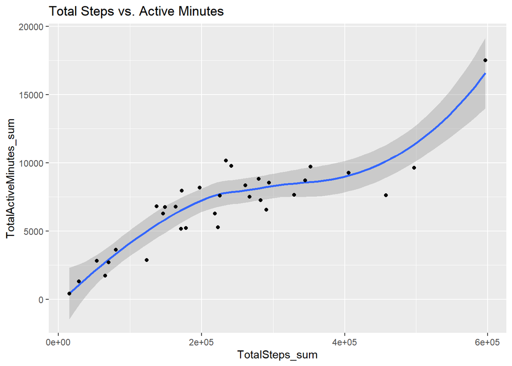

```r
ggplot(data = daily_data_activeminutes_steps, aes(x = TotalSteps_sum, y = TotalActiveMinutes_sum))+ geom_smooth() + geom_point() + labs(title="Total Steps vs. Active Minutes")
```

- We can see a positive correlation between Total Active Minutes and Total Steps.
- As a recommendation: if Bellabeat users want to improve their actives minutes by improving their step counts, the Bellabeat app can recommend increasing step counts.
- Keep in mind that we need to support these insights with more data because the correlation between some data doesn’t mean causation.

### Visualization calories versus total step

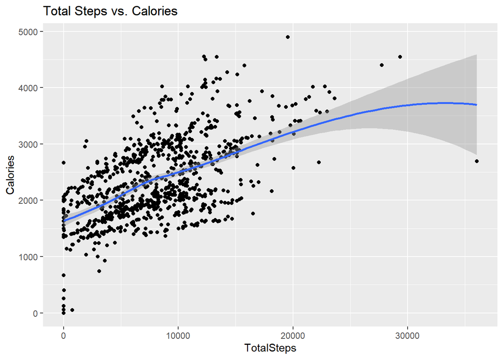

```r
ggplot(data= daily_data, aes(x=TotalSteps, y=Calories)) +
  geom_point() + geom_smooth() + labs(title="Total Steps vs. Calories")
```

### Visualization Total Minutes Asleep versus Sedentary Minutes

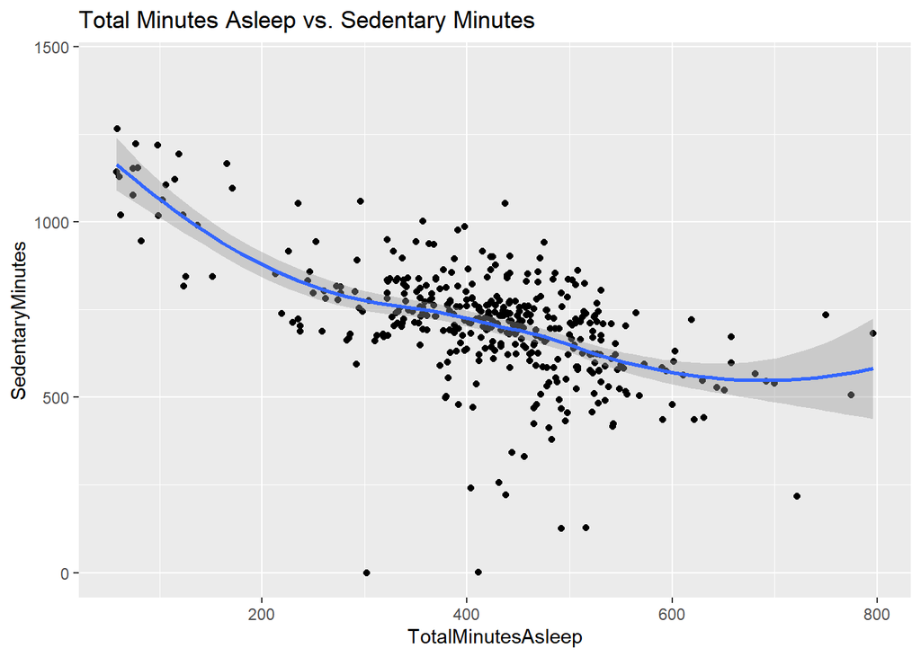

```r
ggplot(data=daily_data, aes(x=TotalMinutesAsleep, y=SedentaryMinutes)) +
      geom_point() + geom_smooth() +
      labs(title="Total Minutes Asleep vs. Sedentary Minutes")
```

- we can see a negative correlation between Sedentary Minutes and Sleep time.
- As a recommendation: if Bellabeat users want to improve their sleep, the Bellabeat app can recommend reducing sedentary time.
- Keep in mind that we need to support these insights with more data because the correlation between some data doesn’t mean causation.

### visualization Total Minutes Asleep versus Total Time in Bed

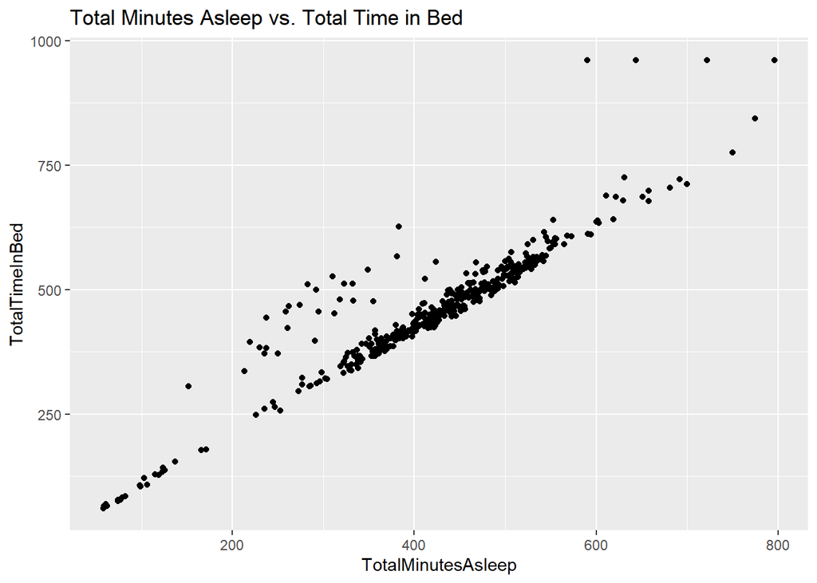

```r
ggplot(data=sleep, aes(x=TotalMinutesAsleep, y=TotalTimeInBed)) +
  geom_point()+ labs(title="Total Minutes Asleep vs. Total Time in Bed")
```

- The relationship between Total Minutes Asleep and Total Time in Bed is a positive linear correlation.
- if the Bellabeat users want to improve their sleep, we should consider using notifications to go to sleep.

## PHASE 6: Act

Thank you for your interest!

This is my first project using R. I would appreciate any comments and recommendations for improvement!